# Network Practice for UROP

Clint McKenna

November 5, 2019

## data prep

I usually start all my scripts off with a code chunk to load in packages, datasets, define custom functions, etc.

```r
# load packages
library(igraph)
library(tidyverse)
# functions
select <- dplyr::select

# read in data
movies <- read.csv('../data/clean/movies.csv')
genres <- read.csv('../data/clean/genres.csv')
genreEdgeList <- read.csv('../data/clean/genreEdgeList.csv')
```

## Previewing Data Files

Here, we will try out some common functions in R to look at the data we are working with.

Lets start by looking at how the genres were listed originally in the data.

```r
# first few rows of dataset
head(genres)
```

```
##   X    id                                    title           genre
## 1 1 19995                                   Avatar          Action
## 2 2 19995                                   Avatar       Adventure
## 3 3 19995                                   Avatar         Fantasy
## 4 4 19995                                   Avatar Science Fiction
## 5 5   285 Pirates of the Caribbean: At World's End       Adventure
## 6 6   285 Pirates of the Caribbean: At World's End         Fantasy
```

```r
# last few rows of dataset
tail(genres)
```

```
##           X     id                     title       genre
## 12155 12155  72766                 Newlyweds     Romance
## 12156 12156 231617 Signed, Sealed, Delivered      Comedy
## 12157 12157 231617 Signed, Sealed, Delivered       Drama
## 12158 12158 231617 Signed, Sealed, Delivered     Romance
## 12159 12159 231617 Signed, Sealed, Delivered    TV Movie
## 12160 12160  25975         My Date with Drew Documentary
```

So each row in the genres dataset is a genre. If a movie has multiple genres, it will have a row for each. If we wanted to inspect a specific movie like Avatar, we can use the tidyverse function filter()

```r
# filter only one title
genres %>%
  filter(title == 'Avatar')
```

```
##   X    id  title           genre
## 1 1 19995 Avatar          Action
## 2 2 19995 Avatar       Adventure
## 3 3 19995 Avatar         Fantasy
## 4 4 19995 Avatar Science Fiction
```

Right now, this data is in “long” format. There is one row for each genre. If a movie has multiple genres, it has one row for each. The first entry, Avatar, has 4: Action, Adventure, Fantasy, and Science Fiction.

How can we reshape the data for network visualization? There are a usually a couple ways that network data is structured: an adjacency matrix and an edge list. For this task, we will focus on an edge list, just because I find that more intuitive.

An edge list has two columns. You can think of each row as a pair of nodes in a network that share an edge of some sort. In this case, it if they both occur in a movie. If we just look at the first movie above, we want a edge list that looks like this:

Action, Adventure Action, Fantasy Action, Science Fiction Adventure, Fantasy Adventure, Science Fiction Fantasy, Science Fiction

If we convert the genres dataset to an edgelist, we get something like the genreEdgeList dataset. Here is a preview.

```r
# preview dataset
head(genreEdgeList)
```

```
##   X    genre1          genre2    title
## 1 1    Action       Adventure     2012
## 2 2    Action Science Fiction     2012
## 3 3 Adventure Science Fiction     2012
## 4 4     Drama          Action 47 Ronin
## 5 5     Drama       Adventure 47 Ronin
## 6 6     Drama         Fantasy 47 Ronin
```

```r
tail(genreEdgeList)
```

```
##       X          genre1          genre2                 title
## 404 404       Adventure          Action X-Men: The Last Stand
## 405 405       Adventure Science Fiction X-Men: The Last Stand
## 406 406       Adventure        Thriller X-Men: The Last Stand
## 407 407          Action Science Fiction X-Men: The Last Stand
## 408 408          Action        Thriller X-Men: The Last Stand
## 409 409 Science Fiction        Thriller X-Men: The Last Stand
```

```r
# just look at avatar
genreEdgeList %>%
  filter(title == 'Avatar')
```

```
##    X    genre1          genre2  title
## 1 14    Action       Adventure Avatar
## 2 15    Action         Fantasy Avatar
## 3 16    Action Science Fiction Avatar
## 4 17 Adventure         Fantasy Avatar
## 5 18 Adventure Science Fiction Avatar
## 6 19   Fantasy Science Fiction Avatar
```

Looks right. It is the same pairings we wrote out above. Now, an edgelist with all the movies in the TMDB data is huge, so just for practice I limited it to the movies with the top 100 budgets.

## Visualizing Network

Now that we have an edglist, we can import it into an igraph function using the igraph package. igraph also has libraries in python and other languages, so its a good one to be familiar with in case you end up doing more work with networks.

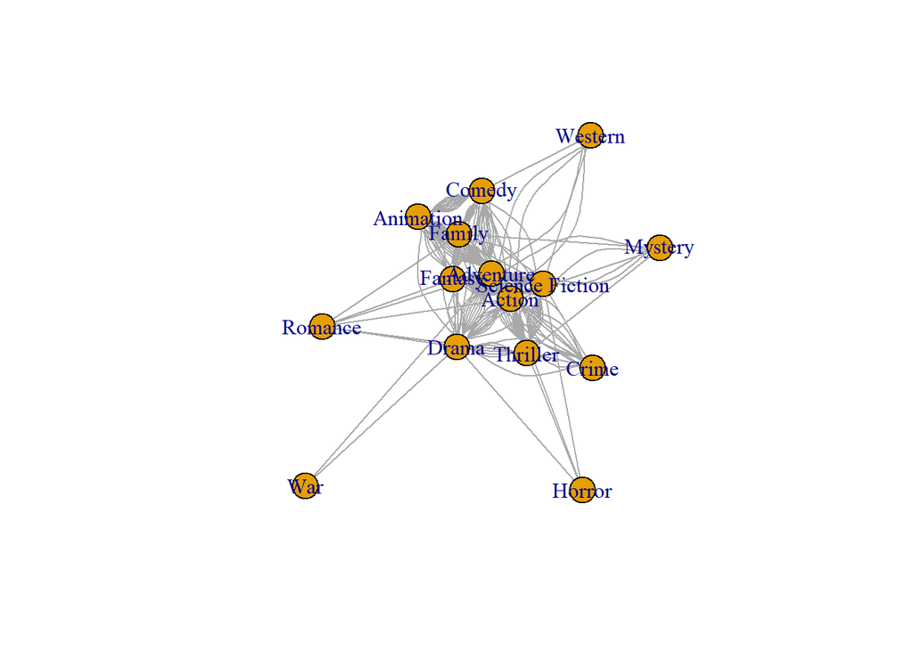

```r
# had to filter out unneccessary columns since igraph didnt like this
genreEdgeList <- genreEdgeList %>%
  select(genre1, genre2, title)

# create network object. non-directed
net <- graph_from_data_frame(
  genreEdgeList,
  directed = FALSE
)

# plot
plot(net)
```

Looks a little whacky to start with. For one, if there are multiple edges between nodes, the plot with make a separate line for each edge. Instead, we want to convert this to a weighted edge (so thicker lines = more cooccurrences of the relationships).

```r
# can check igraph object is weighted
is.weighted(net)
```

```
## [1] FALSE
```

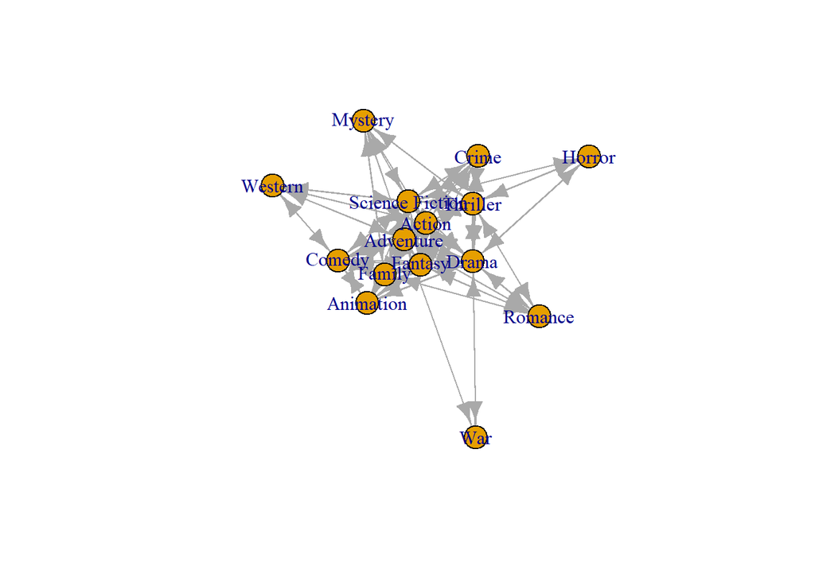

```r
# import again, as weighted
net <- graph.adjacency(get.adjacency(net), weighted=TRUE)

# plot again
plot(net)
```

Looks better, but now there are a ton of arrows. What does this refer to? When importing, igraph thinks that we are using a directed graph (with “sender” and “receiver” nodes). We can specify as undirected to fix that.

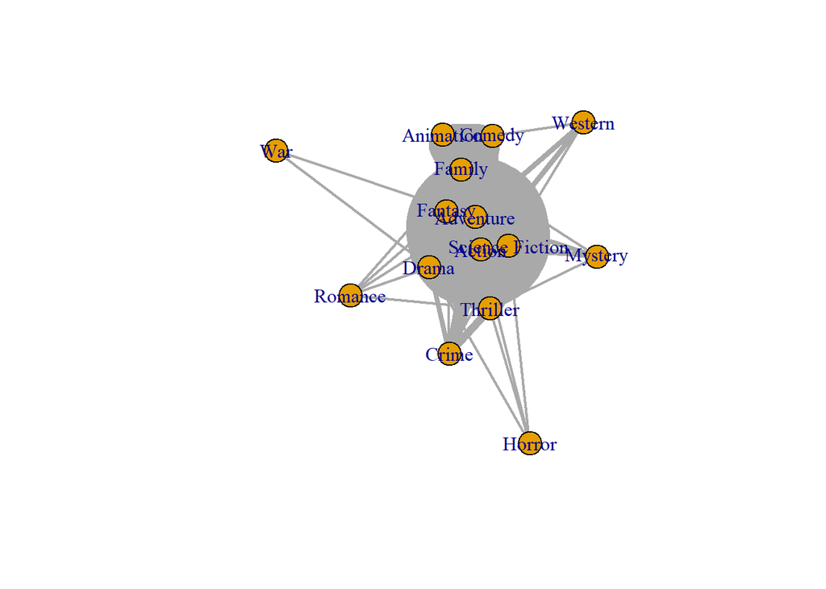

```r
# specify as undirected
net <- as.undirected(net)

# plot
# this time, we will include line thickness as weight
plot(net,
     edge.width = E(net)$weight)
```

The really heavily weighted lines are huge and distoring out graph. We can make this look better by applying some sort of function to the edge width argument, like dividing by a constant. I’ll take the natural log in order to normalize it.

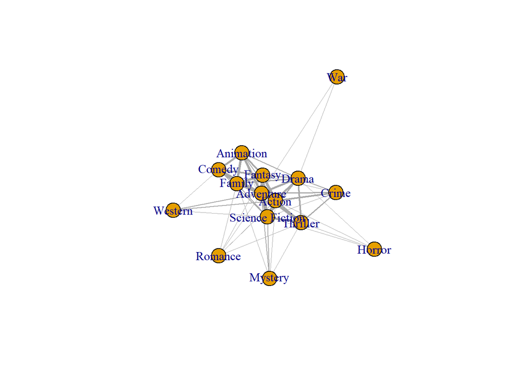

```r
# normalize edge weights in plot
plot(net,
     edge.width = log(E(net)$weight))
```

Note that I could have also just changed the attributes in the igraph object itself. If we check that, you’ll see that it is still heavily skewed.

```r
# check edge attributes of net
edge_attr(net)
```

```
## $weight
##  [1] 116  14  16   4  22   4   8  40   6  32  46  70   6  10  28  30  18
## [18]  12   8  16   2  18  20   8  72  66   6   2   4  12  18   4   2   4
## [35]   2   2   4  10   6   4   2   6   2   2   2   2   2   2   2   2   2
## [52]   2   2   4   4   2   2   2   2
```

We can also do lots of things to jazz up the plots by adding arguments to the plot() function. Here, we can change it to be circular, display the labels of nodes, and change the color.

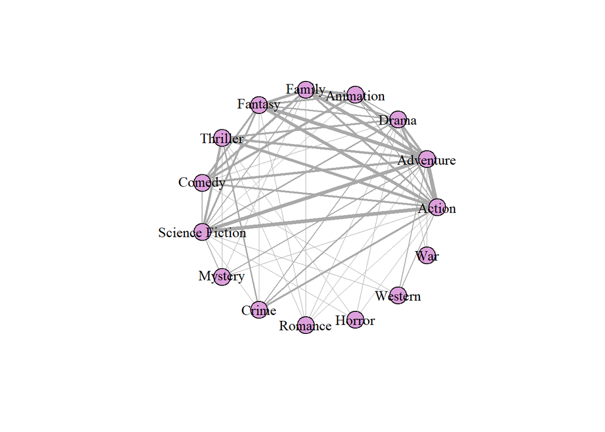

```r
# plot with new arguments
plot(net,
     edge.width = log(E(net)$weight),
     layout = layout_in_circle,
     vertex.label.color='black',
     vertex.shape='circle',
     vertex.color = 'plum')
```

Can also adjust the size of the text and the nodes.

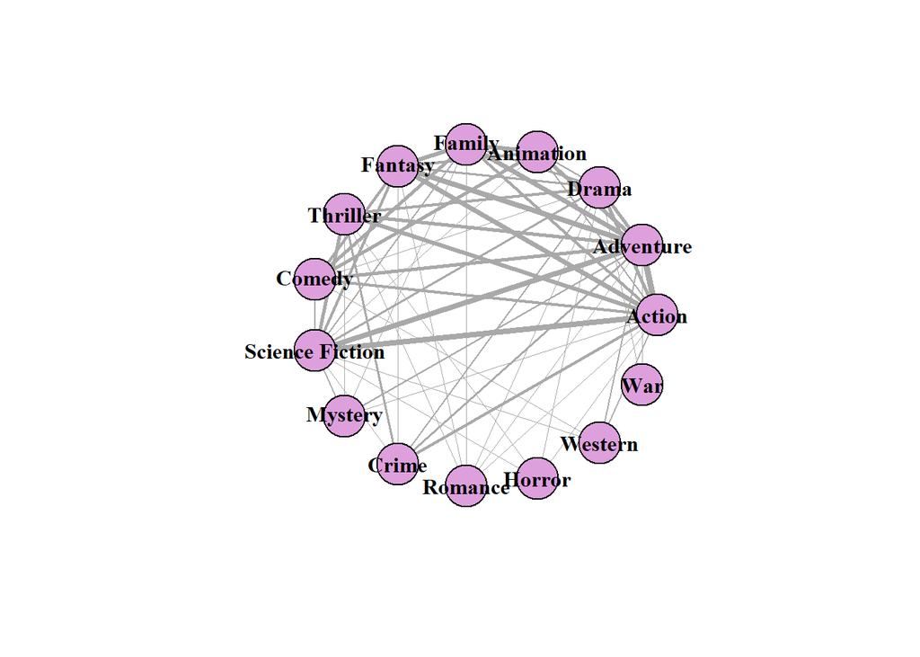

```r
# plot with size arguments
plot(net,
     edge.width = log(E(net)$weight),
     layout = layout_in_circle,
     vertex.label.font = 2,
     vertex.label.color='black',
     vertex.shape='circle',
     vertex.size = 25,
     vertex.color = 'plum')
```

## Degree Centrality of Network

Now, let’s calculate some basic metrics often reported in networks. There are many, but we’ll just look at 3: - *Degree*: degree is a count of the number of neighbors a node has - *Betweenness*: betweenness centrality measures the extent to which a vertex lies on paths between other vertices. - *Eigenvector*: eigenvector centrality - central vertices are those with many central neighbors

```r
# degree
degree(net)
```

```
##          Action       Adventure           Drama       Animation
##              13              13              12               7
##          Family         Fantasy        Thriller          Comedy
##               9               9               8               8
## Science Fiction         Mystery           Crime         Romance
##              12               5               6               6
##          Horror         Western             War
##               4               4               2
```

As you can see, degree is pretty easy to discern from the plot above and very straightforward.

```r
# betweenness
betweenness(net)
```

```
##          Action       Adventure           Drama       Animation
##        5.391667        4.000000       18.741667        0.000000
##          Family         Fantasy        Thriller          Comedy
##        1.191667        3.033333        3.183333        1.833333
## Science Fiction         Mystery           Crime         Romance
##       17.583333        1.666667        3.450000       24.641667
##          Horror         Western             War
##       10.916667        3.333333        1.333333
```

Betweenness makes less sense in this network, but you can think of it like this: does the path between nodes i and j have to go through another node k? For nodes like Animation, the answer is a resounding ‘no’. You’ll see that even though it has decent degree score, it tends to only occur with select other genres.

```r
# eigenvector
eigen_centrality(net)$vector
```

```
##          Action       Adventure           Drama       Animation
##      0.92959320      1.00000000      0.19447958      0.21582740
##          Family         Fantasy        Thriller          Comedy
##      0.35148648      0.60365351      0.27103215      0.18829171
## Science Fiction         Mystery           Crime         Romance
##      0.66434916      0.04344118      0.09005449      0.02981853
##          Horror         Western             War
##      0.01832997      0.04193716      0.01063135
```

Eigenvector centrality measures a node’s influence on the network. It has more involved mathematical calculations from the adjacency matrix. From https://www.sci.unich.it/~francesc/teaching/network/eigenvector.html:

Let $A = (a_{i,j})$ be the adjacency matrix of a graph. The eigenvector centrality $x_{i}$ of node $i$ is given by:
$$x_i = \frac{1}{\lambda} \sum_k a_{k,i} \, x_k$$
where $\lambda \neq 0$ is a constant. In matrix form we have:
$$\lambda x = x A$$

So you can have a node with high eigenvector centrality, but low degree centrality. An example of eigenvector centrality is the PageRank algorithm for Google’s search engine.